# LCI Report for Fredonia Reservoir

NYS Department of Environmental Conservation

December 16, 2018

Just checking to make sure we have only one unique location per lake

```
##          LAKE_ID    LOCATION_ID
## 2780 0105FRE0160 0105FRE0160_DH
```

# Calculations

## Trophic State

| score | clarity | TP.surface | Chla |
| --- | --- | --- | --- |
| 1 | <2 | >0.02 | >8 |
| 2 | 2-5 | 0.01-0.02 | 2-8 |
| 3 | >5 | <0.01 | <2 |

These scores are added together to get a total score

| overall.score | translation |
| --- | --- |
| 3 | eutrophic |
| 6 or <6 | mesotrophic |
| 7 or 8 | mesooligotrophic |
| 9 | oligotrophic |

## Public Water Supply Use

assuming this waterbody is a public water supply

Components:

| short | definition |
| --- | --- |
| UR | number of days PWS use was restricted |
| AT | Additional Treatment |
| MCL | any maximum contamination limit violations reported at the public water supply |
| ChlA | What percent of the Chl A readings since 2011 (or 2018) exceeded the standard (class AA standard is >4, class A standard is >6) |
| HABs | How many days were HABs observed since 2011 (or 2018) |
| BGA | Surface readings of FP-BGChl over 25 since 2011 (or 2018) |
| sHABs | Count of shoreline habs that have FP-BGChl reading over 25 since 2011 |
| Bind | Assuming the lake is neither class B or C, The number of Fe, Mn, As hypolimnion samples that exceeded thresholds OR using inferred DO from aquatic life |

Additional definitions:

- NOTE: inferred DO is calculated in aquatic life table

Questions for Scott

- AT: what does this mean exactly and where are data collected from?
- MCL: how to get this info???
- sHABs: for 2018 calc it’s also since 2011???
- sHABs: this code seems wrong. I would think they should both be the same spreadsheet (it is in the swimming sHABs): COUNTIFS(RawShoreHAB!$AC$2:$AC$500,">25",RawSurfaceAll!$AP$2:$AP$500,“>2011”)
- Bind: Why do you only count Fe readings if there are more than one???
- Bind: the inferred DO value for av year is used but the inferred DO assessment is used for 2018????
- Bind: Why don’t you use Fe, Me, or As values for 2018????????
- ChlA: Shouldn’t ChlA have a -1 value for not being a PWS???
- ALL: Why are the scores different for 2018 vers av year?
- ALL: shouldn’t y2018 use > and not = for comparing max(PWS)???

Components for av year:

| score | UR | AT | MCL | ChlA | HABs | BGA | sHABs | Bind |
| --- | --- | --- | --- | --- | --- | --- | --- | --- |
| -1 | not PWS | not PWS | not PWS |  | not PWS | not PWS | not PWS |  |
| 0 | 0 |  | no | <10% | 0 | 0 | 0 |  |
| 1.3 |  |  |  |  |  |  |  | av As>0.3 OR InferredDO>0 |
| 2.2 |  |  |  |  |  |  | >0 |  |
| 2.3 |  |  |  |  |  |  |  | av Mn>0.1 OR count(Fe>1)>1 |
| 2.4 |  |  |  |  |  | >0 |  |  |
| 2.5 |  |  |  |  | >0 |  |  |  |
| 2.6 |  |  |  | 10%-50% |  |  |  |  |
| 3.3 |  |  |  |  |  |  |  | count(Fe>10)>1 |
| 3.6 |  |  |  | >50% |  |  |  |  |
| 3.7 |  |  | yes |  |  |  |  |  |
| 3.8 |  | is PWS |  |  |  |  |  |  |
| 3.9 | 0-30 |  |  |  |  |  |  |  |
| 4.9 | >30 |  |  |  |  |  |  |  |

Components for 2018

| score | ChlA | HABs | BGA | sHABs | Bind |
| --- | --- | --- | --- | --- | --- |
| -1 |  | not PWS | not PWS | not PWS |  |
| 0 | <10% | 0 | 0 | 0 |  |
| 1.5 |  |  |  |  | InferredDO>0 |
| 2.6 |  |  |  | >0 |  |
| 2.7 |  |  | >0 |  |  |
| 2.8 |  | >0 |  |  |  |
| 2.9 | 10%-50% |  |  |  |  |
| 3.9 | >50% |  |  |  |  |

Total Score for Potable Water Supplies

| score | translation | avYear | y2018 |
| --- | --- | --- | --- |
| 2 | Not Known | notPWS | notPWS |
| 3 | Supported/Good | 0>max(PWS)<1 | 0>max(PWS18)<1 |
| 4 | Threatened/Fair | max(PWS)>1 | max(PWS18)=1 |
| 5 | Stressed/Poor | max(PWS)>2 | max(PWS18)=2 |
| 6 | Impaired | max(PWS)>3 | max(PWS18)=3 |

Primary Issue  
The primary issue is simply the highest scoring component in the list

## Swimming

Components:

| short | definition |
| --- | --- |
| DB | number of days beaches were closed |
| Clarity | Percentage of clarity observations since 2011 (or 2018) less than 1.21 |
| Control | Control measures |
| sTOX | Count of shore samples >4 since 2011 (or 2018) |
| sHABs | Count of shoreline habs that have FP-BGChl reading over 25 since 2011 (or 2018) |
| TOX | Count of surface samples >4 since 2011 (or 2018) |
| BGA | Surface readings of FP-BGChl over 25 since 2011 (or 2018) |
| CT | Trend score for clarity since sampling began |
| HABn | Any HAB notification |

Additional definitions/Notes:

- Trend score = RegScore x Pscore x SIGN
  - RegScore = 0 (if n<5 | r2<0.3), 1 (if 0.03<=r2<0.5), 2 (if r2>=0.5)
  - PScore = 0 (if n<5 | p>0.05), 1 (if 0.01<p<=0.05), 2 (if p<=0.01)
  - SIGN = 0 (if slope=0), 1 (if slope is +), -1 (if slope is -)

Questions for Scott:

- Control: What would these be? Where is this data collected?
- sTOX: what is this parameter in the database???
- HABn: excel descriptor is >1 but the formula looks for any at all
- HABn: I’m presuming this is the listing on the website?
- sHABs18: =0 is repeated in this equation: =IF($B$9="no",-1,IF($G$21=0,0,IF($G$21=0,0,IF($G$21=1,1.7,2.7))))
- AvYr: for total score, shouldn’t it be 2 if it doesn’t have a beach?

Components for av year:

| score | DB | Clarity | Control | sTOX | sHABs | TOX | BGA | CT | HABn |
| --- | --- | --- | --- | --- | --- | --- | --- | --- | --- |
| -1 |  |  |  | no beach | no beach |  |  |  | no beach |
| 0 | no beach | <=10 | no | 0 | 0 | <1 | <1 | any other score | no |
| 1.2 |  |  |  |  |  |  |  | =2 |  |
| 1.3 |  |  |  |  |  |  | 1 |  |  |
| 1.4 |  |  |  |  |  | 1 |  |  |  |
| 1.5 |  |  |  |  | 1 |  |  |  |  |
| 1.6 |  |  |  | 1 |  |  |  |  |  |
| 2.1 |  |  |  |  |  |  |  |  | only 1 |
| 2.2 |  |  |  |  |  |  |  | =4 |  |
| 2.3 |  |  |  |  |  |  | >1 |  |  |
| 2.4 |  |  |  |  |  | >1 |  |  |  |
| 2.5 |  |  |  |  | >1 |  |  |  |  |
| 2.6 |  |  |  | >1 |  |  |  |  |  |
| 2.8 |  | >10 |  |  |  |  |  |  |  |
| 2.9 | >10 |  |  |  |  |  |  |  |  |
| 3 | 0<x<10 |  |  |  |  |  |  |  |  |
| 3.1 |  |  |  |  |  |  |  |  | >1 |
| 3.7 |  |  | !no |  |  |  |  |  |  |
| 3.8 |  | >50 |  |  |  |  |  |  |  |

Components for 2018:

| score | Clarity | sTOX | sHABs | TOX | BGA | HABn |
| --- | --- | --- | --- | --- | --- | --- |
| -1 |  | no beach | no beach | no beach | no beach | no beach |
| 0 | <=10 | 0 | 0 | <1\|0 | <1 | “no” |
| 1.5 |  |  |  |  | 1 |  |
| 1.6 |  |  |  | 1 |  |  |
| 1.7 |  |  | 1 |  |  |  |
| 1.8 |  | 1 |  |  |  |  |
| 2.4 |  |  |  |  |  | only 1 |
| 2.5 |  |  |  |  | >1 |  |
| 2.6 |  |  |  | >1 |  |  |
| 2.7 |  |  | >1 |  |  |  |
| 2.8 | >10 | >1 |  |  |  |  |
| 3.4 |  |  |  |  |  | >1 |
| 3.9 | >50 |  |  |  |  |  |

Total Score for Swimming

| score | translation | avYear | y2018 |
| --- | --- | --- | --- |
| 2 | Not Known |  |  |
| 3 | Supported/Good | 0>max(SWIM)<1 | 0>max(SWIM18)<1 |
| 4 | Threatened/Fair | max(SWIM)>1 | max(SWIM18)=1 |
| 5 | Stressed/Poor | max(SWIM)>2 | max(SWIM18)=2 |
| 6 | Impaired | max(SWIM)>3 | max(SWIM18)=3 |

Primary Issue  
The primary issue is simply the highest scoring component in the list

# Secchi Depth

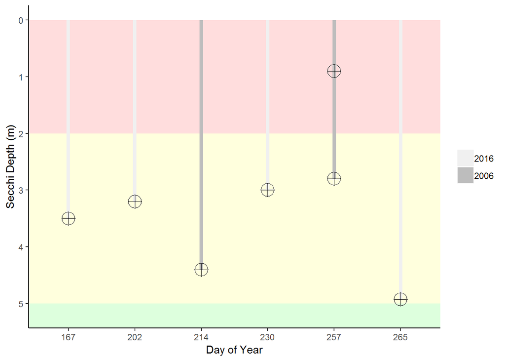